# Usando Regressão Linear para Explicar a votação de Deputados

Gabriel Morais Lúcio de Araújo

22 de novembro de 2017

```r
eleicoes2014 <- read.csv("~/Github/analiseDeDados/dados/eleicoes2014.csv", encoding = "latin1")
```

### 1. Um modelo de regressão múltipla com todas as variáveis é plausível para explicar a variação em y (número de votos)? Justifique sua resposta.

```r
# Coluna recursos_de_outros_candidatos.comites
eleicoes2014$recursos_de_outros_candidatos.comites[is.na(eleicoes2014$recursos_de_outros_candidatos.comites)] <- median(eleicoes2014$recursos_de_outros_candidatos.comites, na.rm = TRUE)
# Coluna recursos_de_partidos
eleicoes2014$recursos_de_partidos[is.na(eleicoes2014$recursos_de_partidos)] <- median(eleicoes2014$recursos_de_partidos, na.rm = TRUE)
# Coluna recursos_de_pessoas_físicas
eleicoes2014$recursos_de_pessoas_físicas[is.na(eleicoes2014$recursos_de_pessoas_físicas)] <- median(eleicoes2014$recursos_de_pessoas_físicas, na.rm = TRUE)
# Coluna recursos_de_pessoas_juridicas
eleicoes2014$recursos_de_pessoas_juridicas[is.na(eleicoes2014$recursos_de_pessoas_juridicas)] <- median(eleicoes2014$recursos_de_pessoas_juridicas, na.rm = TRUE)
# Coluna recursos_proprios
eleicoes2014$recursos_proprios[is.na(eleicoes2014$recursos_proprios)] <- median(eleicoes2014$recursos_proprios, na.rm = TRUE)
```

Agora que essas variáveis foram preenchidas partirei para a questão a ser respondida.

```r
eleicoes2014.semCategoricas1 <- eleicoes2014 %>%
  select(-cargo, -nome, -sequencial_candidato, -numero_cadidato, -setor_economico_receita, -setor_economico_despesa)
```

O modelo linear com todas as variáveis não é plausível para explicar o comportamento da variável votos. Existem muitas variáveis categoricas, assim o modelo fica longo e de dificil visualização. Por esse motivo eu retirei as seguintes variáveis: cargo, nome, sequencial_candidato, numero_candidato, setor_economico_receita e setor_economico_despesa. Após isso obtive a seguinte sumarização de meu modelo:

```r
lm(data = eleicoes2014.semCategoricas1, votos ~ .) %>% summary()
```

```
##
## Call:
## lm(formula = votos ~ ., data = eleicoes2014.semCategoricas1)
##
## Residuals:
##     Min      1Q  Median      3Q     Max
## -300288   -7949   -1395    4009 1228948
##
## Coefficients:
##                                         Estimate Std. Error t value
## (Intercept)                           -2.875e+03  6.888e+03  -0.417
## UFAL                                   1.589e+04  6.429e+03   2.471
## UFAM                                   1.485e+04  6.755e+03   2.198
## UFAP                                   8.568e+03  6.281e+03   1.364
## UFBA                                   1.950e+04  5.568e+03   3.502
## UFCE                                   2.254e+04  5.720e+03   3.941
## UFDF                                   9.792e+03  6.030e+03   1.624
## UFES                                   1.392e+04  5.940e+03   2.344
## UFGO                                   1.343e+04  6.535e+03   2.056
## UFMA                                   2.206e+04  5.795e+03   3.806
## UFMG                                   1.525e+04  5.254e+03   2.903
## UFMS                                   2.673e+03  6.021e+03   0.444
## UFMT                                   9.148e+03  6.579e+03   1.391
## UFPA                                   2.037e+04  5.800e+03   3.512
## UFPB                                   2.534e+04  6.468e+03   3.917
## UFPE                                   2.228e+04  6.016e+03   3.704
## UFPI                                   1.609e+04  6.541e+03   2.461
## UFPR                                   1.749e+04  5.504e+03   3.177
## UFRJ                                   1.381e+04  5.166e+03   2.674
## UFRN                                   2.221e+04  6.487e+03   3.424
## UFRO                                   6.938e+03  6.512e+03   1.065
## UFRR                                   8.562e+03  6.422e+03   1.333
## UFRS                                   1.769e+04  5.479e+03   3.228
## UFSC                                   2.166e+04  6.161e+03   3.516
## UFSE                                   2.057e+04  6.788e+03   3.031
## UFSP                                   1.514e+04  5.120e+03   2.957
## UFTO                                   4.493e+03  7.110e+03   0.632
## partidoPC do B                        -1.181e+04  5.388e+03  -2.192
## partidoPCB                            -6.112e+03  7.476e+03  -0.818
## partidoPCO                            -4.536e+03  1.197e+04  -0.379
```

[output cut: 128 more lines]

```
## grauENSINO MÉDIO COMPLETO             0.706088
## grauENSINO MÉDIO INCOMPLETO           0.754470
## grauLÊ E ESCREVE                      0.943217
## grauSUPERIOR COMPLETO                 0.167257
## grauSUPERIOR INCOMPLETO               0.608630
## estado_civilDIVORCIADO(A)             0.952637
## estado_civilSEPARADO(A) JUDICIALMENTE 0.223417
## estado_civilSOLTEIRO(A)               0.778043
## estado_civilVIÚVO(A)                  0.089704 .
## ---
## Signif. codes:  0 '***' 0.001 '**' 0.01 '*' 0.05 '.' 0.1 ' ' 1
##
## Residual standard error: 32230 on 4069 degrees of freedom
## Multiple R-squared:  0.5034, Adjusted R-squared:  0.4934
## F-statistic:  50.3 on 82 and 4069 DF,  p-value: < 2.2e-16
```

Mesmo retirando algumas variáveis categoricas, ainda existem muitas. Além disso, existem muitas onde o valor-p é maior que 0,05, ou seja, a probabilidade da causalidade entra ela e o número de votos seja aleatória é alta. Então, irei retirar mais variáveis, são elas: estado_civil, grau, idade e quantidade_doacoes. Ficamos então com:

```r
eleicoes2014.semCategoricas2 <- eleicoes2014.semCategoricas1 %>%
  select(-estado_civil, -grau, -idade, -quantidade_doacoes)

lm(data = eleicoes2014.semCategoricas2, votos ~ .) %>% summary()
```

```
##
## Call:
## lm(formula = votos ~ ., data = eleicoes2014.semCategoricas2)
##
## Residuals:
##     Min      1Q  Median      3Q     Max
## -303868   -7923   -1505    3943 1231954
##
## Coefficients:
##                                         Estimate Std. Error t value
## (Intercept)                            7.276e+02  5.948e+03   0.122
## UFAL                                   1.517e+04  6.417e+03   2.364
## UFAM                                   1.452e+04  6.744e+03   2.153
## UFAP                                   8.355e+03  6.273e+03   1.332
## UFBA                                   1.921e+04  5.562e+03   3.453
## UFCE                                   2.232e+04  5.706e+03   3.912
## UFDF                                   1.021e+04  6.026e+03   1.695
## UFES                                   1.389e+04  5.923e+03   2.345
## UFGO                                   1.308e+04  6.526e+03   2.005
## UFMA                                   2.225e+04  5.785e+03   3.847
## UFMG                                   1.506e+04  5.246e+03   2.871
## UFMS                                   2.495e+03  6.017e+03   0.415
## UFMT                                   8.674e+03  6.574e+03   1.319
## UFPA                                   2.034e+04  5.793e+03   3.512
## UFPB                                   2.538e+04  6.459e+03   3.928
## UFPE                                   2.148e+04  5.997e+03   3.582
## UFPI                                   1.581e+04  6.529e+03   2.422
## UFPR                                   1.724e+04  5.492e+03   3.138
## UFRJ                                   1.353e+04  5.160e+03   2.622
## UFRN                                   2.205e+04  6.478e+03   3.405
## UFRO                                   6.609e+03  6.505e+03   1.016
## UFRR                                   8.314e+03  6.413e+03   1.296
## UFRS                                   1.719e+04  5.471e+03   3.143
## UFSC                                   2.166e+04  6.155e+03   3.520
## UFSE                                   1.985e+04  6.767e+03   2.934
## UFSP                                   1.501e+04  5.115e+03   2.934
## UFTO                                   4.390e+03  7.102e+03   0.618
## partidoPC do B                        -1.244e+04  5.376e+03  -2.315
## partidoPCB                            -6.209e+03  7.459e+03  -0.832
## partidoPCO                            -5.065e+03  1.194e+04  -0.424
```

[output cut: 104 more lines]

```
## recursos_de_partidos                   < 2e-16 ***
## recursos_de_pessoas_físicas           2.77e-15 ***
## recursos_de_pessoas_juridicas         1.68e-15 ***
## recursos_proprios                      < 2e-16 ***
## quantidade_despesas                    < 2e-16 ***
## quantidade_fornecedores                < 2e-16 ***
## total_despesa                         0.000586 ***
## media_despesa                         3.66e-06 ***
## sexoMASCULINO                         0.048897 *
## ---
## Signif. codes:  0 '***' 0.001 '**' 0.01 '*' 0.05 '.' 0.1 ' ' 1
##
## Residual standard error: 32240 on 4081 degrees of freedom
## Multiple R-squared:  0.5016, Adjusted R-squared:  0.4931
## F-statistic: 58.68 on 70 and 4081 DF,  p-value: < 2.2e-16
```

### 2. Todas as variáveis são úteis para o modelo de regressão? Há variáveis redudantes? Justifique sua resposta em ambos os casos.

Para descobrir variáveis redundantes irei utilizar de correlação entre elas.

```r
eleicoes2014.filtrado.numeric <- eleicoes2014.semCategoricas2
eleicoes2014.filtrado.numeric$UF <- as.numeric(eleicoes2014.filtrado.numeric$UF)
eleicoes2014.filtrado.numeric$sexo  <- as.numeric(eleicoes2014.filtrado.numeric$sexo )
eleicoes2014.filtrado.numeric$partido <- as.numeric(eleicoes2014.filtrado.numeric$partido)
corr = cor(eleicoes2014.filtrado.numeric[, 1:14])
round(corr, 2)
```

```
##                                          UF partido quantidade_doadores
## UF                                     1.00    0.00                0.00
## partido                                0.00    1.00                0.04
## quantidade_doadores                    0.00    0.04                1.00
## total_receita                         -0.02   -0.04                0.46
## media_receita                         -0.09   -0.08                0.09
## recursos_de_outros_candidatos.comites  0.01   -0.05                0.20
## recursos_de_partidos                  -0.02   -0.06                0.24
## recursos_de_pessoas_físicas           -0.03    0.03                0.63
## recursos_de_pessoas_juridicas         -0.01    0.00                0.42
## recursos_proprios                     -0.03   -0.02                0.15
## votos                                 -0.01   -0.04                0.42
## quantidade_despesas                   -0.01   -0.02                0.48
## quantidade_fornecedores               -0.04   -0.01                0.44
## total_despesa                         -0.02   -0.04                0.46
##                                       total_receita media_receita
## UF                                            -0.02         -0.09
## partido                                       -0.04         -0.08
## quantidade_doadores                            0.46          0.09
## total_receita                                  1.00          0.60
## media_receita                                  0.60          1.00
## recursos_de_outros_candidatos.comites          0.42          0.19
## recursos_de_partidos                           0.82          0.59
## recursos_de_pessoas_físicas                    0.57          0.22
## recursos_de_pessoas_juridicas                  0.80          0.40
## recursos_proprios                              0.38          0.20
## votos                                          0.62          0.43
## quantidade_despesas                            0.81          0.38
## quantidade_fornecedores                        0.72          0.33
## total_despesa                                  0.99          0.59
##                                       recursos_de_outros_candidatos.comites
## UF                                                                     0.01
## partido                                                               -0.05
## quantidade_doadores                                                    0.20
## total_receita                                                          0.42
## media_receita                                                          0.19
## recursos_de_outros_candidatos.comites                                  1.00
## recursos_de_partidos                                                   0.23
## recursos_de_pessoas_físicas                                            0.24
## recursos_de_pessoas_juridicas                                          0.25
```

[output cut: 95 more lines]

```
##                                       total_despesa
## UF                                            -0.02
## partido                                       -0.04
## quantidade_doadores                            0.46
## total_receita                                  0.99
## media_receita                                  0.59
## recursos_de_outros_candidatos.comites          0.42
## recursos_de_partidos                           0.81
## recursos_de_pessoas_físicas                    0.57
## recursos_de_pessoas_juridicas                  0.80
## recursos_proprios                              0.37
## votos                                          0.61
## quantidade_despesas                            0.81
## quantidade_fornecedores                        0.72
## total_despesa                                  1.00
```

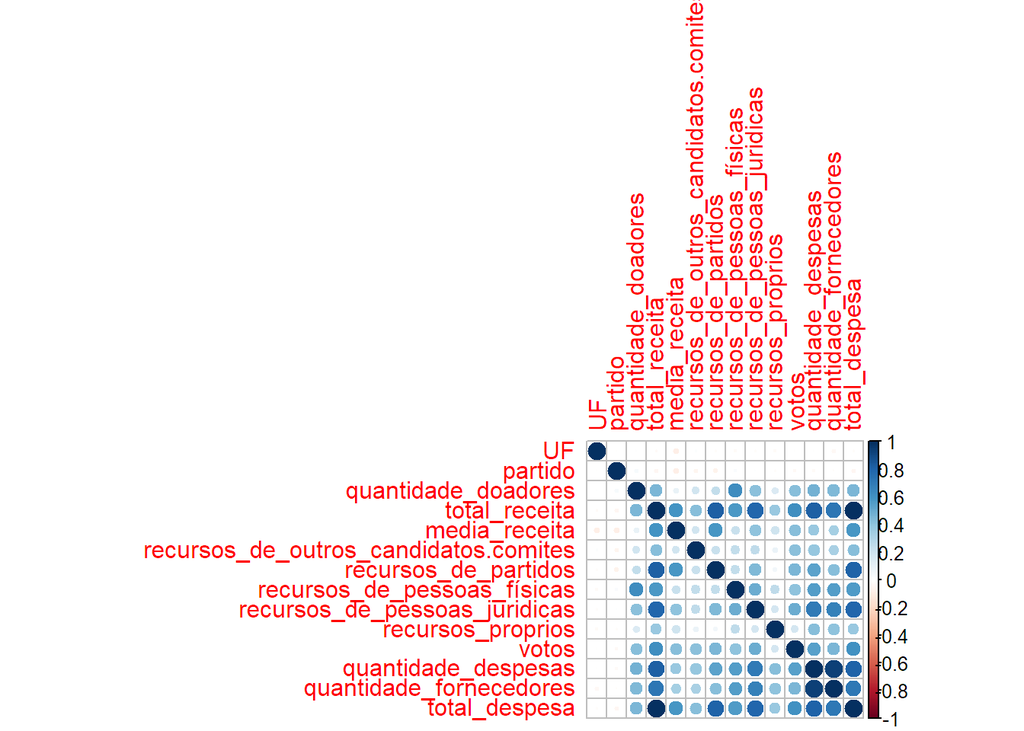

```r
corrplot(corr)
```

```r
eleicoes2014.semCategoricas3 <- eleicoes2014.semCategoricas2 %>%
  select(-total_receita)
```

### 3. No caso de haver variáveis pouco explicativas e/ou redudantes, construa um novo modelo sem essas variáveis e o compare ao modelo com todas as variáveis (e.g. em termos de R2 e RSE).

```r
modelo <- lm(data = eleicoes2014.semCategoricas3, votos ~ .)
summary(modelo)
```

```
##
## Call:
## lm(formula = votos ~ ., data = eleicoes2014.semCategoricas3)
##
## Residuals:
##     Min      1Q  Median      3Q     Max
## -314121   -7443   -2013    2782 1226589
##
## Coefficients:
##                                         Estimate Std. Error t value
## (Intercept)                           -1.092e+04  5.861e+03  -1.864
## UFAL                                   1.452e+04  6.479e+03   2.241
## UFAM                                   1.420e+04  6.809e+03   2.086
## UFAP                                   7.886e+03  6.334e+03   1.245
## UFBA                                   1.880e+04  5.616e+03   3.348
## UFCE                                   2.070e+04  5.759e+03   3.595
## UFDF                                   1.093e+04  6.083e+03   1.796
## UFES                                   1.451e+04  5.979e+03   2.427
## UFGO                                   1.068e+04  6.583e+03   1.622
## UFMA                                   2.095e+04  5.839e+03   3.588
## UFMG                                   1.498e+04  5.297e+03   2.828
## UFMS                                   7.924e+02  6.072e+03   0.130
## UFMT                                   6.879e+03  6.635e+03   1.037
## UFPA                                   2.053e+04  5.849e+03   3.510
## UFPB                                   2.533e+04  6.522e+03   3.883
## UFPE                                   2.030e+04  6.054e+03   3.353
## UFPI                                   1.637e+04  6.592e+03   2.484
## UFPR                                   1.763e+04  5.545e+03   3.180
## UFRJ                                   1.194e+04  5.207e+03   2.294
## UFRN                                   2.111e+04  6.540e+03   3.228
## UFRO                                   6.504e+03  6.568e+03   0.990
## UFRR                                   7.435e+03  6.474e+03   1.148
## UFRS                                   1.713e+04  5.524e+03   3.102
## UFSC                                   2.160e+04  6.214e+03   3.477
## UFSE                                   1.837e+04  6.831e+03   2.690
## UFSP                                   1.498e+04  5.164e+03   2.900
## UFTO                                   3.667e+03  7.170e+03   0.511
## partidoPC do B                        -1.121e+04  5.426e+03  -2.066
## partidoPCB                            -9.487e+03  7.522e+03  -1.261
## partidoPCO                            -9.123e+03  1.204e+04  -0.757
```

[output cut: 102 more lines]

```
## recursos_de_partidos                  0.008800 **
## recursos_de_pessoas_físicas           0.008437 **
## recursos_de_pessoas_juridicas         0.000345 ***
## recursos_proprios                     0.306630
## quantidade_despesas                    < 2e-16 ***
## quantidade_fornecedores                < 2e-16 ***
## total_despesa                         0.076647 .
## media_despesa                         1.25e-08 ***
## sexoMASCULINO                         0.000816 ***
## ---
## Signif. codes:  0 '***' 0.001 '**' 0.01 '*' 0.05 '.' 0.1 ' ' 1
##
## Residual standard error: 32550 on 4082 degrees of freedom
## Multiple R-squared:  0.4918, Adjusted R-squared:  0.4832
## F-statistic: 57.25 on 69 and 4082 DF,  p-value: < 2.2e-16
```

No modelo feito na 1 pergunta obtive RSE = 32230 e R² = 0,5034. No novo modelo, retirando a variável considerada redundante obtive RSE = 32550 e R² = 0,4918. A variação desses valores foi baixa entre os modelos.

### 4. Analise plots de resíduos e verifique se há tendências nos erros.

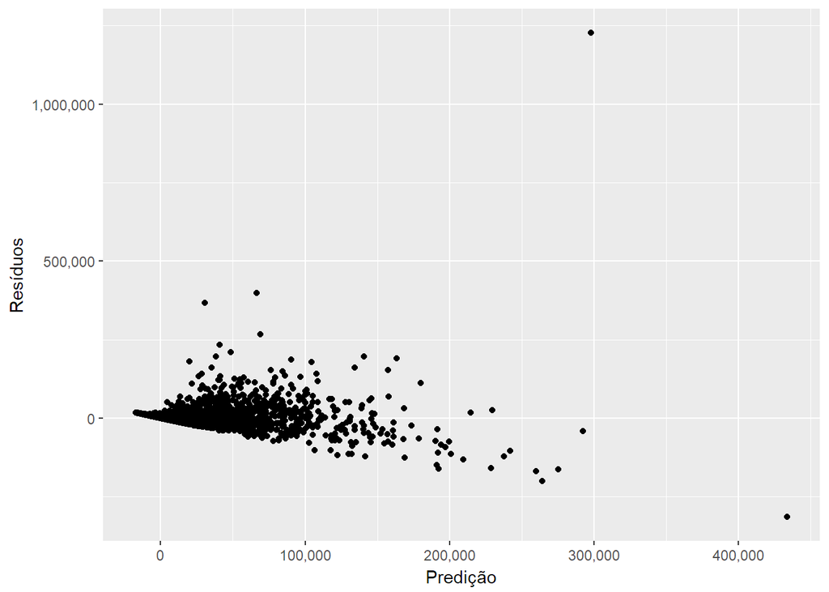

```r
ggplot(modelo, aes(x = predict(modelo), y = residuals(modelo))) +
  geom_point() +
  scale_y_continuous(labels = scales::comma) +
  scale_x_continuous(labels = scales::comma) +
  labs("Analíse de resíduos", x = "Predição", y = "Resíduos")
```

Os dados estão, de certa forma, concentrados e não são aleátorios. Isso indica que o modelo ainda precisa de aprimoramentos.

### 5. Quais variáveis conseguem explicar melhor o número de votos? Justifique sua resposta.

As variáveis com menor p-valor são fortes concorrentes, pois o p-valor indica quão aleátoria é a correlação entre uma variável e a variável resposta. Com isso quantidade_despesas, quantidade_fornecedores, quantidade_doadores, media_receita e recursos_de_outros_candidatos.comites são variáveis que, provavelmente, consegur melhor explicar o número de votos.